# CEE118X_HW1

Bill Li

9/24/2021

```
## [1] "PGE_2017_Q1_ElectricUsageByZip.csv"
```

```
## [1] "PGE_2018_Q1_ElectricUsageByZip.csv"
```

```
## [1] "PGE_2019_Q1_ElectricUsageByZip.csv"
```

```
## [1] "PGE_2020_Q1_ElectricUsageByZip.csv"
```

```
## [1] "PGE_2017_Q2_ElectricUsageByZip.csv"
```

```
## [1] "PGE_2018_Q2_ElectricUsageByZip.csv"
```

```
## [1] "PGE_2019_Q2_ElectricUsageByZip.csv"
```

```
## [1] "PGE_2020_Q2_ElectricUsageByZip.csv"
```

```
## [1] "PGE_2017_Q3_ElectricUsageByZip.csv"
```

```
## [1] "PGE_2018_Q3_ElectricUsageByZip.csv"
```

```
## [1] "PGE_2019_Q3_ElectricUsageByZip.csv"
```

```
## [1] "PGE_2020_Q3_ElectricUsageByZip.csv"
```

```
## [1] "PGE_2017_Q4_ElectricUsageByZip.csv"
```

```
## [1] "PGE_2018_Q4_ElectricUsageByZip.csv"
```

```
## [1] "PGE_2019_Q4_ElectricUsageByZip.csv"
```

```
## [1] "PGE_2020_Q4_ElectricUsageByZip.csv"
```

*Just created pge_17to20_ele.csv so from 2017 to 2020 electricity data.

```
## [1] "PGE_2017_Q1_GasUsageByZip.csv"
```

```
## [1] "PGE_2018_Q1_GasUsageByZip.csv"
```

```
## [1] "PGE_2019_Q1_GasUsageByZip.csv"
```

```
## [1] "PGE_2020_Q1_GasUsageByZip.csv"
```

```
## [1] "PGE_2017_Q2_GasUsageByZip.csv"
```

```
## [1] "PGE_2018_Q2_GasUsageByZip.csv"
```

```
## [1] "PGE_2019_Q2_GasUsageByZip.csv"
```

```
## [1] "PGE_2020_Q2_GasUsageByZip.csv"
```

```
## [1] "PGE_2017_Q3_GasUsageByZip.csv"
```

```
## [1] "PGE_2018_Q3_GasUsageByZip.csv"
```

```
## [1] "PGE_2019_Q3_GasUsageByZip.csv"
```

```
## [1] "PGE_2020_Q3_GasUsageByZip.csv"
```

```
## [1] "PGE_2017_Q4_GasUsageByZip.csv"
```

```
## [1] "PGE_2018_Q4_GasUsageByZip.csv"
```

```
## [1] "PGE_2019_Q4_GasUsageByZip.csv"
```

```
## [1] "PGE_2020_Q4_GasUsageByZip.csv"
```

*Just created pge_17to20_gas.csv so from 2017 to 2020 gas data.

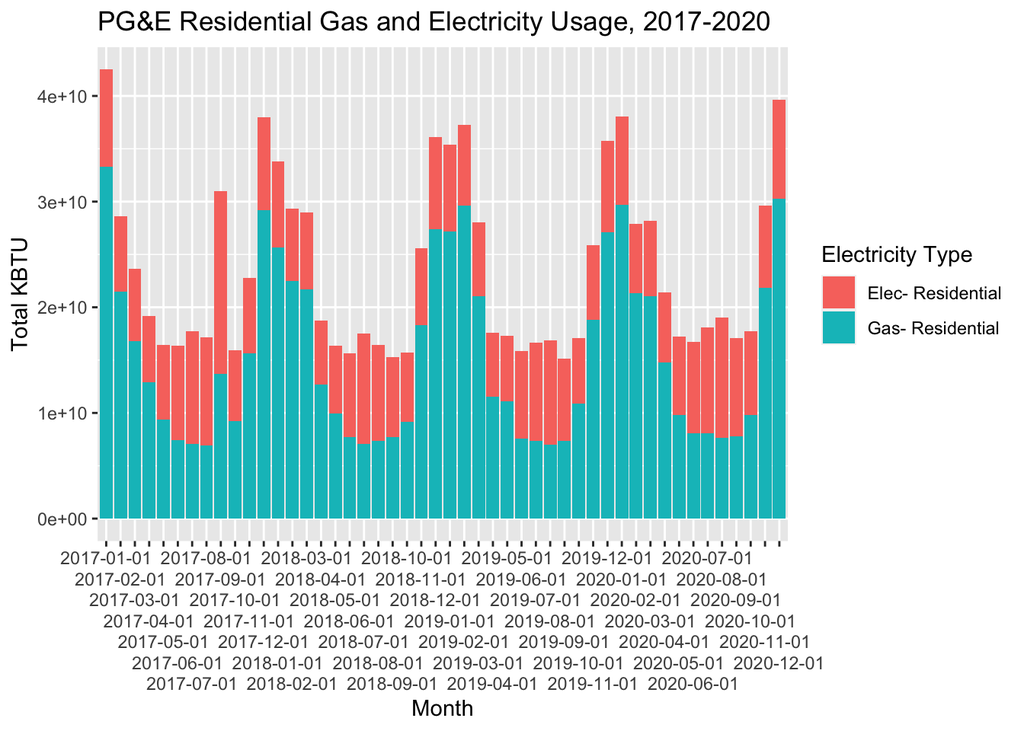

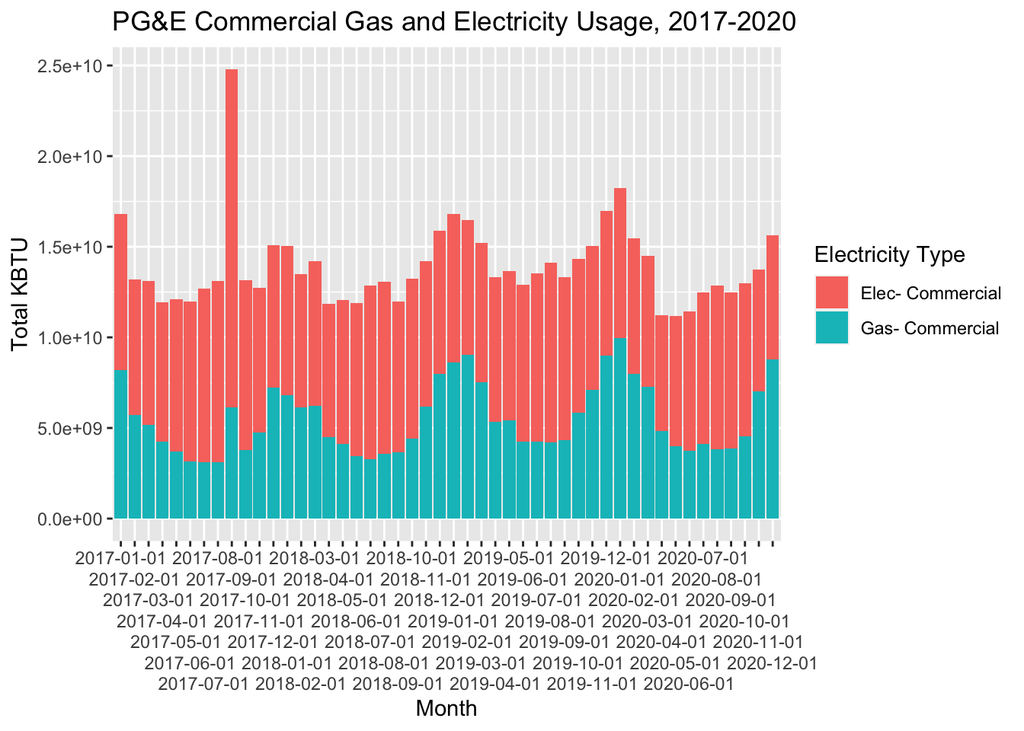

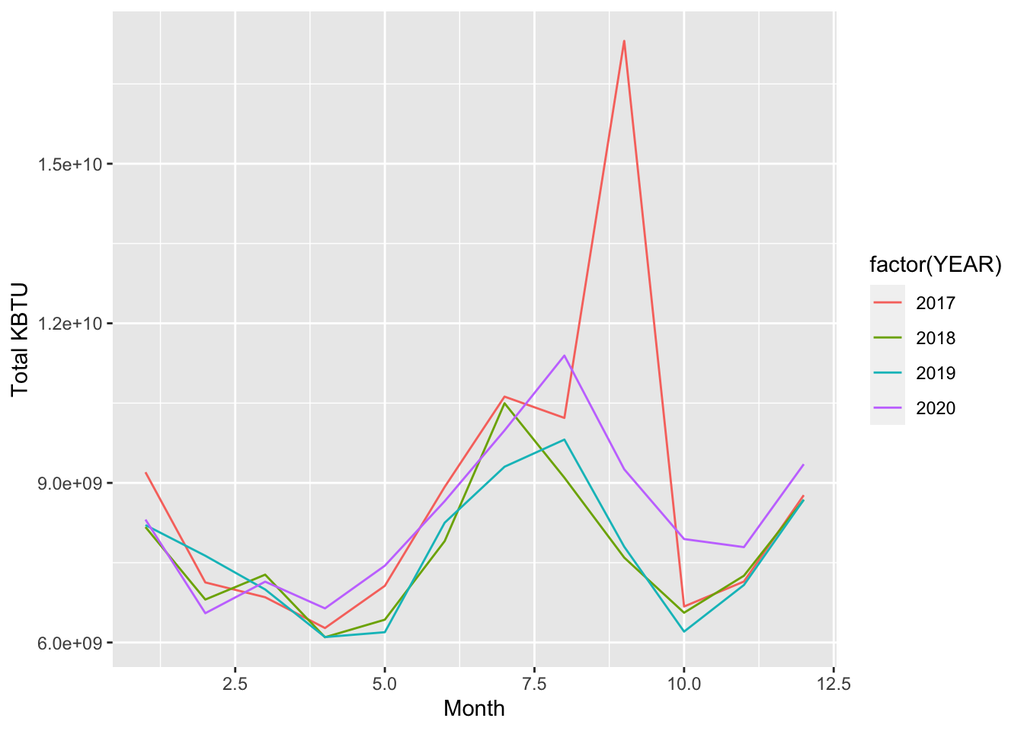

Ans:Based on the line chart above, residential electricity usage went up in 2020 from August to December comparing to the data from 2018 and 2019. There seems to be a sharp increase in residential electricity usage in 2017 between August and October.

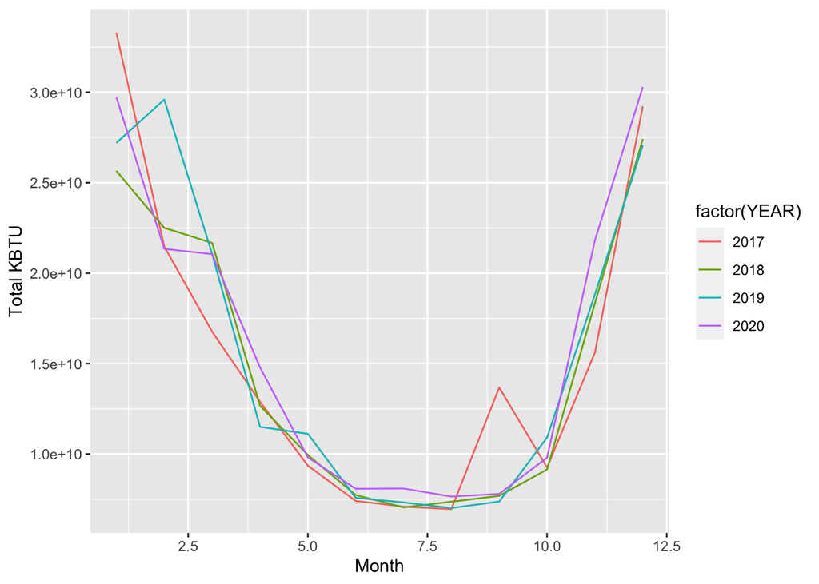

Ans: Based on the line chart above, residential gas usage in 2020 is about the same as the rest of the years with a slight increase from late October to December. There is a sharp increase in gas usage between August and October in 2017.

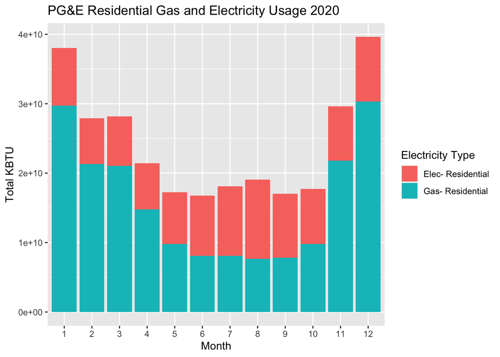

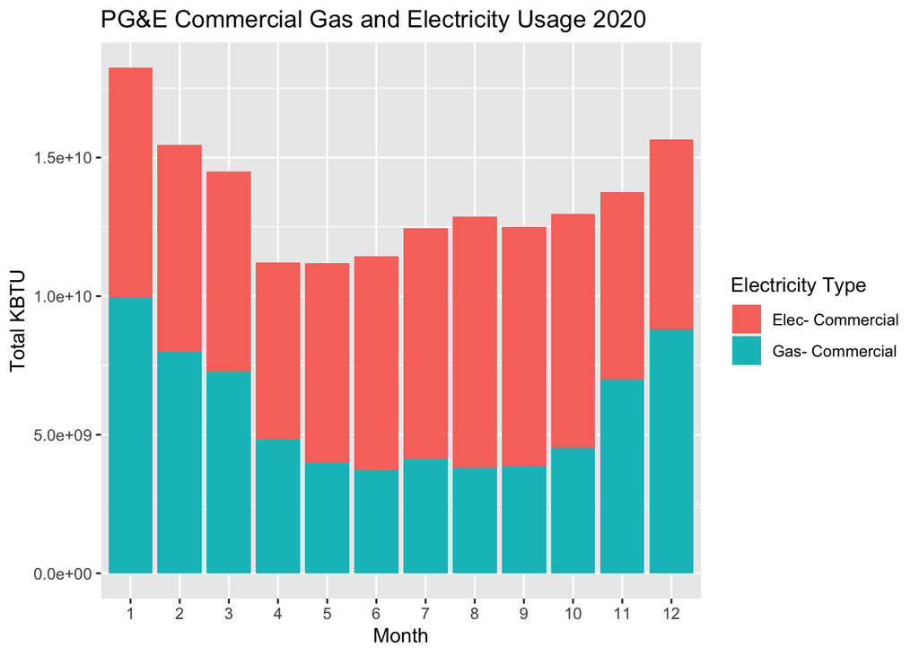

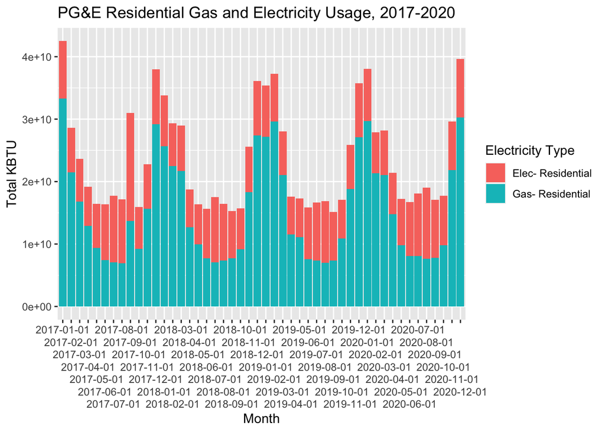

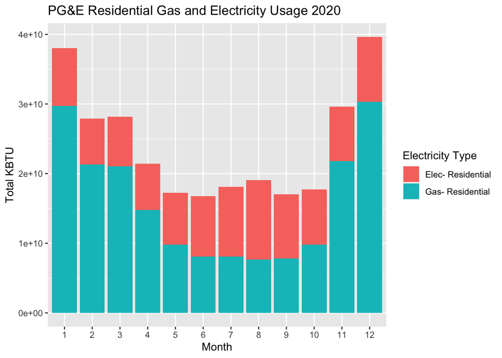

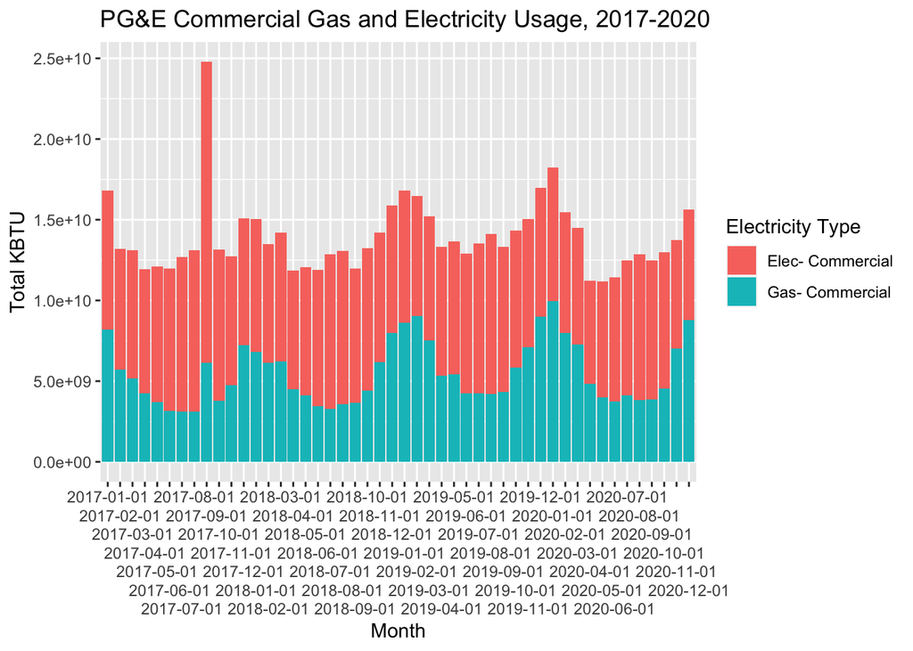

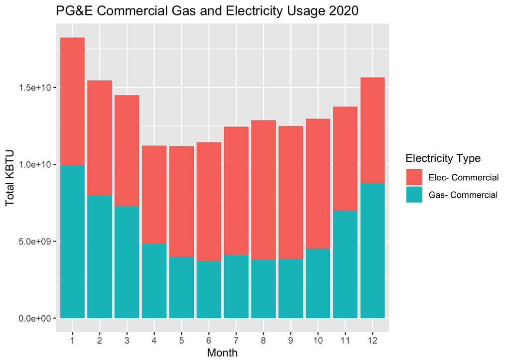

*ANS: For both residential and commercial electricity and gas usage, the general trend is similar for pre-pandemic and covid era. Both Commercial and Residential use more gas in the winter and more electricity in the summer. In the 2017-2020 data, I did not distinguish the various years in my data. As a result, variations in certain months of years can be mask by the chart. We assume that monthly data are similar among these years in this case.